# China Fantasy Report

## Introduction

Nǐ hǎo managers and welcome back to the Ahead At The Apex Fantasy League, for the Chinese Grand Prix report. The first sprint race of the season is finally under our belt and the new regulations are once again under the spotlight for producing some interesting racing. If you want to hear our thoughts on the weekend, head over to the [Patreon](https://www.patreon.com/posts/from-our-f1-gp-153215291?utm_medium=clipboard_copy&utm_source=copyLink&utm_campaign=postshare_creator&utm_content=join_link), for now let's get into the fantasy league scores.

## Fantasy League Scores

Scores for drivers/constructors in the current year's fantasy league, along with manager/team points, values, and statistics. Note: driver and constructor values are taken as the cost to enter the current race and are updated the week before the race.

## Lineup Scores

On the weekend that Kimi Antonelli took his first Grand Prix victory, he also tops the more important fantasy league weekly table with a score of 68 points, leaps ahead of Charles Leclerc in second place with 51 and Lewis Hamilton in third place with 48. Teammate Russell is next with 45 points, ahead of Liam Lawson with 35. Down at the slow end, Gabriel Bortoleto and Lance Stroll come away with -14 points, behind Lando Norris with -10. Then we have Albon, Alonso, and Piastri with -7 points in third, followed by Bottas with 3 points. Rounding out the bottom five is Arvid Lindblad and Nico Hulkenberg with 7 points.

Ferrari top the weekly charts in China with 119 points, just 4 ahead of nearest rivals Mercedes with 115 points in second place. In third we have surprise of the season so far, Haas, with 65 points. No shock that Aston Martin are at the bottom this week with -20 points, followed by McLaren with -7 and Audi with -4 points.

Antonelli snatches the lead of the championship and makes our first triple digits of the year with 100 points, ahead of Russell with 84 points. Then we have Charles Leclerc snapping at their heels in third place with 80 points, followed by teammate Hamilton with 73 points. Rounding out the top five is Max Verstappen with 64 points. Lance Stroll is pulling away at the bottom with -37 points, followed by teammate Alonso and Piastri with -21. Then we have Bottas and Hulkenberg with -13 points, and Bortoleto with -1. Alex Albon rounds out the bottom five with 1 singular point.

Mercedes are our championship leaders after 2 rounds with 211 points, with Ferrari in second with 188 points. Haas are a distant, but impressive third place with 99 points. In last place we have Aston Martin with -58 points, some way behind Audi with -4 points. Rounding out the bottom three, but only just, is Cadillac with 9 points.

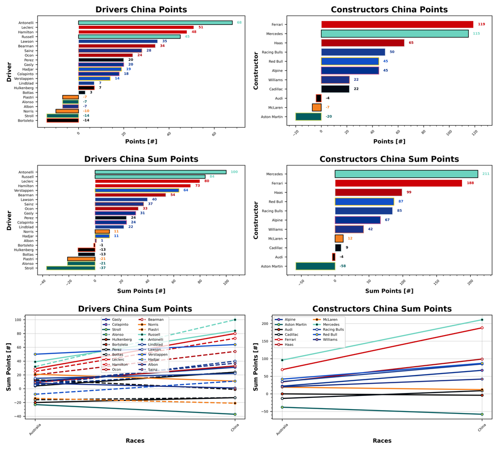

Not a huge shift in prices this week, Verstappen, Russell, Norris, Piastri, and Antonelli are still your expensive 5 at 28.0, 27.7, 27.1, 25.2, and 23.5 respectively. Bottas and Perez are still your cheapest pairing at 5.3 and 5.8, followed by Hulkenberg at 6.2, Lawson at 6.3, and Colapinto at 6.4.

Mercedes remain your most expensive team at 29.6, followed by McLaren at 28.8 and Red Bull at 28.5. Then, at the back, we have Cadillac at 5.4, Audi at 6.0, and Racing Bulls at 6.9.

All values are in Million Dollars.

We have a string of drivers that are already shy of scoring positive points in all races, those are: Norris, Hulkenberg, Hadjar, Bottas, Bortoleto, Albon, Stroll, Piastri, and Alonso; the last three have yet to score any positive points at all. Constructor wise, McLaren and Cadillac have only scored positively in 50% of the races, whereas Audi and Aston Martin are yet to score positively this year.

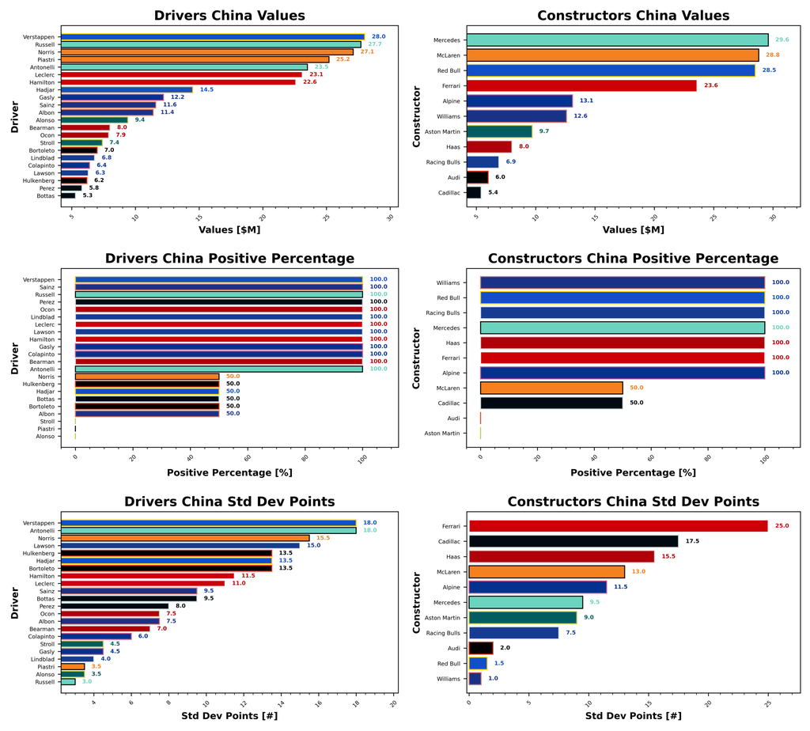

So far you're most consistent driver is George Russell with a standard deviation of 3 (i.e., 3 points variation from weekend to weekend), he's joined by Piastri and Alonso who have been consistently rubbish so far, Lindblad with 4, and Stroll and Gasly with 4.5 for different reasons. Your least consistent drivers are Verstappen and Antonelli with a standard deviation of 18, though not for necessarily bad reasons, followed by Norris with 15.5 and Lawson with 15.

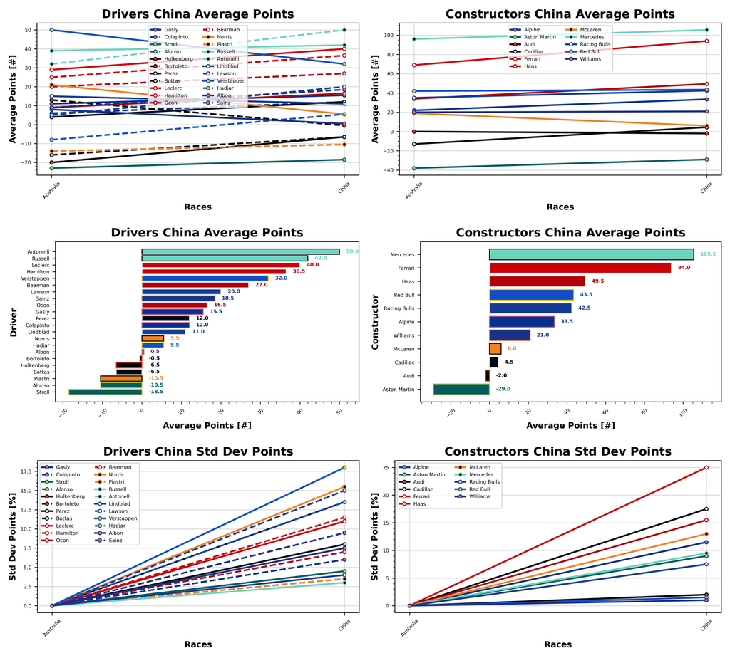

Driver of the week goes to Liam Lawson with a points per value of 5.56 ppm. He's joined by driver of the season Ollie Bearman with a 4.25 ppm, and Sergio Perez with 3.45 ppm. In fourth place, we have Esteban Ocon with 3.04 ppm, and Kimi Antonelli with 2.89 ppm. At the back, it's Bortoleto who is the worst driver of the week with a points per value of -2.0 ppm, followed by Stroll with -1.89 ppm and Alonso with -0.74 ppm. Then we have Albon with -0.61 ppm and reigning champion Lando Norris with -0.37 ppm.

Haas are your team of the week with a points per value of 8.12 ppm, ahead of Racing Bulls with 7.25 ppm, these two are basically equal for team of the season so far too, very impressive. In third place we have Ferrari with 5.04 ppm. Aston Martin are by far the worst team of the week, and in fact season so far, with a points per value of -2.06 ppm. Next we have Audi with -0.67 ppm and McLaren with -0.24 ppm.

ppm = points per million Dollars.

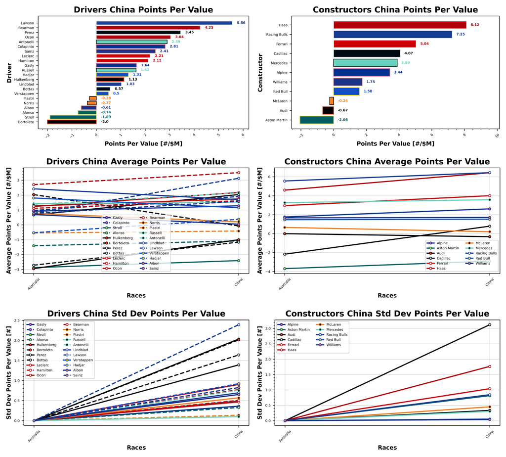

### Manager Scores

It's a return to form this week for Stefanus and Haryanto with 483 points from the first sprint race of the year, and as was the case all of last year, Patrick is hot on his heels with Charles' Eclair F1 with 464 points. Then we have a pair of teams from Josh, Panasonic Toyota Racing with 441 and HSBC Jaguar Racing with 435 points. Rounding out the top five is Cameron with lights out and awaywego with 413 points.

It's Valerie who takes the honours at the bottom this week with Stroll to the 18th with -34 points, then we have Jake and Rory Eat Your Heart Out with -26 points. Will is next with Pay Drivers and -5 points, followed by Stuart and Tyrell P34 6 Wheel Buggy with -3 points. Rounding out the bottom five is Sam and PadCocks with -1 point.

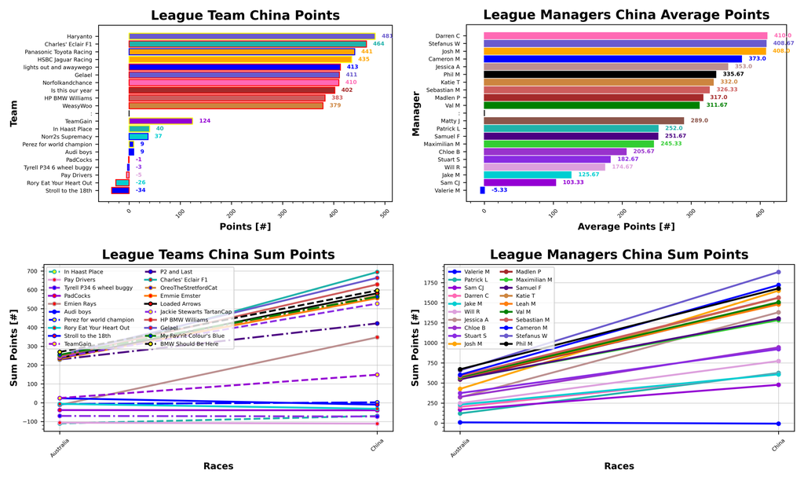

Patrick holds the early lead in the standings with Charles' Eclair F1 and 695 points, followed by a pair of Stefanus teams, Haryanto first with 672 and Gelael in third with 664 points. Then we have Sebastian with HP BMW Williams and 629 points in fourth place. Rookie Darren and Norfolkandchance round out the top five with 613 points.

At the bottom, it's Will and Pay Drivers who lead the way with -111 points, ahead of Stuart and Tyrell P34 6 wheel buggy with -73 points. Then we have Patrick and In Haast Place with -70 points, followed by Sam and PadCocks with -40 points. Rounding out the bottom five is Jake and Rory Eat Your Heart Out with -32 points.

There's plenty of movement throughout the field this week, but our biggest winner is Josh and Panasonic Toyota Racing who jump 34 places in the standings. Our biggest loser is Samuel and P2 and Last who drop 27 places.

We have a handful of penalties this week too, but mainly it's Jake and Rory Eat Your Heart Out who decided to take a -30 penalty instead of using a wildcard token to give themselves very little wiggle room on the Golf League title.

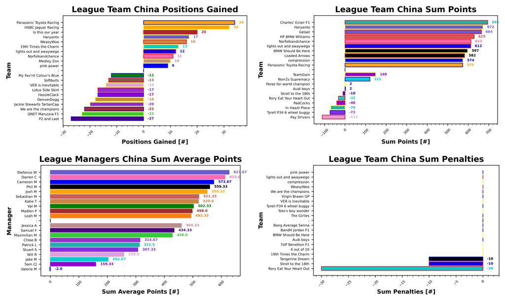

Bearman remains your most popular driver this week with a use count of 38. He's followed by Hulkenberg with 26 and Russell with 24 selections. Then we have Lindblad and Bottas with 21, followed by Bortoleto with 20. Your least chosen drivers were Ocon, Albon, and Piastri with 2 each, then Norris with 4. Stroll, Hamilton, and Alonso are next with 8 selections, followed by Verstappen, Sainz, and Antonelli with 10. Finally we have Lawson and Colapinto with 11 selections each.

Ferrari are your most selected team again with 22 uses, followed by Mercedes with 21 and Haas with 20. McLaren was your least selected team with 4 uses, followed by Red Bull and Williams with 5. Then we have Aston Martin and Alpine with 6 selections each.

George Russell was your most boosted driver this week with a total of 18 selections, followed by Verstappen and Leclerc with a pair of 9s. Then we have Hamilton and Bottas with 5 selections each. The first sprint means our first flurry of perks, and we have a lot. 7 No Negative, 4 Wildcard, 4 Extra DRS, and a Limitless token were used this week to maximise the output of the sprint weekend. Russell made 3 Extra DRS uses this week, and Sergio Perez made 1.

Please note, teams are only checked if their weekly scores do not match a copy-paste team sheet. Teams are checked at the end of the season to ensure accurate statistics.

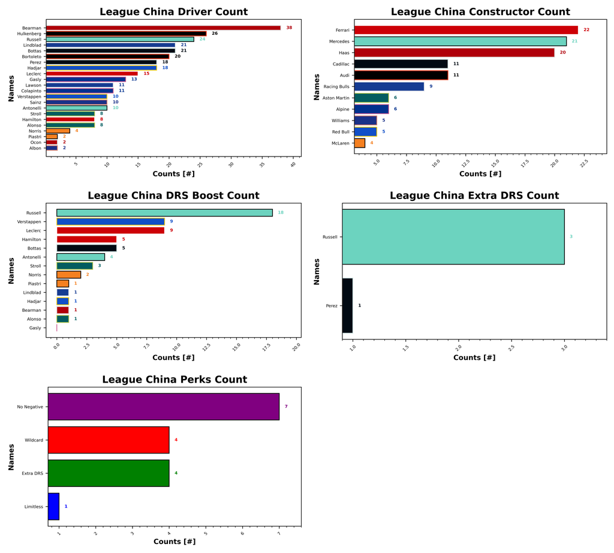

## Prizes

Prizes tracking coming soon, there's little point at this stage reporting on progress, we've had 1 race of some of the prizes so far.

### Championship

| Prize Name | Prize Value | Terms | Manager | Team | Score |
| --- | --- | --- | --- | --- | --- |
|  | (%) |  |  |  |  |
| The World Champion | 20 | Awarded to the top scorer in the league at the end of the season |  |  |  |
| Nobody Remembers Who Came Second | 10 | Awarded to the second place scorer in the league at the end of the season |  |  |  |
| Hulkenberg Podium | 5 | Awarded to the third place scorer in the league at the end of the season |  |  |  |
| Below Par | 20 | Awarded to the lowest scorer in the league at the end of the season, commonly referred to as the Golf League |  |  |  |

### Regions

| Prize Name | Prize Value | Terms | Manager | Team | Score |
| --- | --- | --- | --- | --- | --- |
|  | (%) |  |  |  |  |
| Early Morning Starts | 4 | Awarded to the top scorer in the races in Asia [Australia, China, Japan, Bahrain, Saudi Arabia, Azerbaijan, Singapore, Qatar, and Abu Dhabi] |  |  |  |
| The Glits and Glam | 4 | Awarded to the top scorer in the races in America [Miami, Canada, USA, Mexico, Brazil, Las Vegas] |  |  |  |
| The Home of Motorsport | 4 | Awarded to the top scorer in the races in Europe [Monaco, Barcelona, Austria, Great Britain, Belgium, Hungary, Netherlands, Italy, Spain] |  |  |  |

### Races

| Prize Name | Prize Value | Terms | Managers | Teams | Scores |
| --- | --- | --- | --- | --- | --- |
|  | (%) |  |  |  |  |
| Sprint King | 4 | Highest score across the sprint races [China, Miami, Canada, Belgium, Netherlands, Singapore] |  |  |  |
| Under the Lights | 4 | Lowest score across the night races [Bahrain, Saudi Arabia, Singapore, Las Vegas, Qatar, Abu Dhabi] |  |  |  |
| If You're Not First, You're Last | 4 | Lowest Scores in First and Last Race [Australia, Abu Dhabi] |  |  |  |

### Season

| Prize Name | Prize Value | Terms | Manager | Team(s) | Score |
| --- | --- | --- | --- | --- | --- |
|  | (%) |  |  |  |  |
| Manager of the Year | 3 | Highest manager points per value across all entered teams |  |  |  |
| Jackpot | 3 | Highest weekly score of the year |  |  |  |
| Bogie | 3 | Lowest weekly score of the year |  |  |  |
| Extra Mega DRS | 3 | Highest extra DRS token score |  |  |  |

## F1 Predict

Phil takes the honours this week with a score of 109 points (30%), ahead of Josh with 65 points (40%). Valerie is in third place with 45 points (30%), followed by Val with 32 points (20%). Matty and Stuart both scored 0 this week.

Phil takes the lead in the standings with 198 points (35%), ahead of Valerie with 175 points (40%) and Val with 158 points (30%). Josh is in fourth place with 142 points (45%), with Stuart in fifth with 49 points (20%). Matty is still on 0.

## Next Up

The early morning starts continue as we head to Japan for the next round of the 2026 season, and the final race for a month. Best of luck to you all.